# Practical 2: Foundations (Part 1)

# Python Conditions

**NoteConnections**

This is a short recap of material covered in Code Camp’s [Truth & Conditions](https://jreades.github.io/code-camp/lessons/Boolean_Logic.html) and, to some extent, the [Iteration](https://jreades.github.io/fsds/sessions/week2.html#pre-recorded-lectures) lecture.

## Working with Conditions

Use `if`, `elif`, and `else` so that you get the following output:

1. When `hours` is 10 or more, then the code prints `At least 10 hours worked!`
2. When `hours` is exactly 2, then the code prints `Exactly 2 hours worked.`
3. When `hours` is 9 or less *but not 2*, then the code prints `Less than 10 hours worked!`

**TipHint**

You will *also* need to think about the order in which these conditions are tested.

#### Question

```python
hours = 2

if hours ??:
    print(" ")
elif hours ??:
    print(" ")
else:
    print(" ")
```

## Flow Control

Using the flow chart shown in the image below as a model, write the code to make this condition work. You will need to complete the code such that it produces the following: 1. When `a = 2` and `b = 2` four lines of output will be written 2. When `a = 1` and `b = 2` one line of output will be written

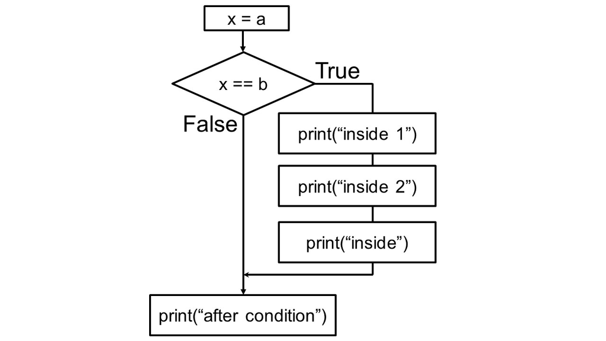

#### Question

```python
a = 1
b = 1

# <your code here>
??
```

# Python Logic

**NoteConnections**

This is a short recap of Code Camp’s [Boolean Logic](https://jreades.github.io/code-camp/lessons/Boolean_Logic.html) session and the [Pthon: the Basics](https://jreades.github.io/fsds//sessions/week2.html#lectures) lecture.

## It’s All Quite Logical…

Before adding a value for `x` and running the code below, try to answer the following questions:

#### Question

1. What names are name(s) are printed when `x = 5`?
2. What value(s) can `x` be when the names `Joe` and `Aled` are printed?
3. What name(s) are printed when `x = -1`?
4. Is there any value for which all three names will be printed?

```python
x = ??

if x > 0 and x < 5:
    print("Joe")

if x > 0 or x < 5:
    print("Aled")

if not(x > 0):
    print("Sarah")
```

## Logic (Cont’d)

Study the flow chart below.

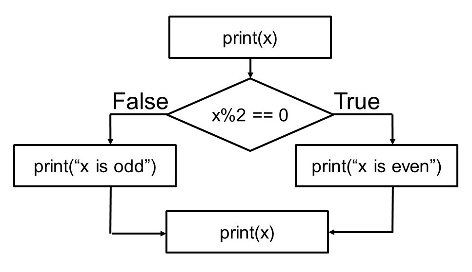

**Tip**

This will require you to combine logic with one of the operators that we saw earlier. Also note the *new* iterator that we’ve got here: `range(<start>, <stop>)` to create a `range` of numbers between two other numbers.

In the cell below, use the for loop *already set up* to as a starting point for implementing the flow chart shown above for values of `x` between 0 and 9.

#### Question

```python
for x in range(0,9):
    #... do something...
    ??
```

## ‘Nested’ Conditionals

Conditional statements can be nested within one another. That is, Python evaluates the first, or ‘outer’, condition and can then evaluate secondary, or ‘inner’, conditions. The code below shows an example of this.

#### Question

```python
x = 5
y = 4

if x != y:                                 #line 1
    print("x is not equal to y")

    if(x > y):                             #line 4
        print("x is greater than y")

    else:                                  #line 7
        print("x is less than y")

else:
    print("<insert conclusion here>")
```

Note how the indentation makes it easier to work out which ‘level’ (outer or inner condition) the code is operating on. In the code above, lines 4 and 7 are at the same indentation meaning that *both will be skipped* if the initial condition (on line 1) is `False`.

To check you understand how the code above works:

1. Change `<insert conclusion here>` to a string that explains the condition of `x` and `y`
2. For `x = 2` and `y = 3`, type what line(s) will be output here: …

Great! You should now have a pretty good understanding of how conditional and logical operators work. This understanding will be handy in future as we work through other computational concepts.

# Python Lists

**NoteConnections**

This is a short recap of material covered in the [Lists](https://jreades.github.io/fsds/sessions/week2.html#lectures) lecture and Code Camp’s [Lists](https://jreades.github.io/code-camp/lessons/Lists.html) session.

## Who’s in the List?

Here we are looking to interact with lists in a straightforward way that will help you to understand accessing them using indexes and slices, and searching.

#### Question

```python
cities = ['New York', 'London', 'Beijing', 'Tokyo', 'Delhi']

# Print out London from cities:
print( ?? )

# Print out Tokyo using *negative* indexing:
print( ?? )

# Print out Beijing *and* Tokyo using a list slice
print( ?? )

# Print out London to Delhi using a slice
print( ?? ) # You could also do cities[1:5] but this way is neater

# Combine positive and negative indexing to print out London, Beijing and Tokyo using a list slice
print( ?? )

# Print out the index for New York by searching for it (i.e. you can't just type 0)
print( ?? )
```

## Manipulating Lists

Let’s break a few things…

### Create an IndexError

#### Question

```python
# Cause an 'IndexError: list index out of range' errr
??
```

### Create a ValueError

#### Question

```python
# Cause a ValueError using the city of Toronto
??
```

### Sort the List

Sort the list *in place* in reverse alphabetical order (i.e. z…a) and then print the sorted list

#### Question

```python
??
print(cities)
```

The output from this should be: `[‘Tokyo’, ‘New York’, ‘London’, ‘Delhi’, ‘Beijing’]`

## Adding/Removing Values

### Inserting into a List

Add the city of Toronto to the list *after* New York in the *sorted* list.

#### Question

```python
# Just in case you make a mistake...
cities = ['Tokyo', 'New York', 'London', 'Delhi', 'Beijing']

??
print(cities)
```

The output should be: `[‘Tokyo’, ‘New York’, ‘Toronto’, ‘London’, ‘Delhi’, ‘Beijing’]`

### Removing from a List

Now *pop* New York from the list *without* specifying its index (i.e. the number `1` should *not* appear in your code). Print out the value that you popped and the print out the cities list to check you’ve done the right thing…

#### Question

```python
??
print(p)
print(cities)
```

The output should be:

- `New York`
- `[‘Tokyo’, ‘Toronto’, ‘London’, ‘Delhi’, ‘Beijing’]`

### Checking Lists

Finally, how can you check if the city of Moscow is in the list and let the user know if it is or is not?

#### Question

```python
if ??
    ??
else:
    ??
```

## You’re Done!

This is quite a lot to get through. If you’ve managed it in under 2 hours then *congratulations*! Either you must have paid a lot of attention when doing Code Camp, or you might want to check in with us as to whether you should really be doing this module…

### No Wait, One More Thing…

You now want to add/commit/push your completed notebook to your GitHub reposistory. Using the Terminal you need to:

1. Navigate to your repository (e.g.`$HOME/Documents/CASA/<your repository>`).
2. Check the status of your notebooks using `git status` (you should see that `Practical-02-Foundations_1.ipynb has been modified`).
3. Add the *changes* to Git using `git add Practical-02-Foundations_1.ipynb`
4. Commit this changed notebook with a message using `git commit -m "<your message here...>"`
5. Push this change to GitHub using: `git push`

You should now be able to visit your repository on [GitHub](https://github.com/) and see that your changes are now stored there as well!